Homework 4: StackOverflow

Load Packages

```r
library(ggplot2) #for visu
library(GGally)
library(boot)
library(tm)
library(SnowballC)
library(wordcloud)
library(MASS)
library(caTools)
library(dplyr)
library(rpart)
library(rpart.plot)
library(randomForest)
library(caret)
library(tm.plugin.webmining)
```

Question a): Cleaning up the dataset

Function to compute accuracy of a classification model

```r
tableAccuracy <- function(test, pred) {
  t = table(test, pred)
  a = sum(diag(t))/length(test)
  return(a)
}
```

Load the data set

```r
Questions = read.csv("ggplot2questions2016_17.csv", stringsAsFactors=FALSE)
```

Create corpuses of the Title and the body

```r
Qtitle = Corpus(VectorSource(Questions$Title))
Qbody = Corpus(VectorSource(Questions$Body))

strwrap(Qbody[[1]])
```

```
##  [1] "<p>I seem to be having trouble setting up a ribbon in ggplot2 to"
##  [2] "display. </p>"
##  [3] ""
##  [4] "<p>Here's a made up data set:</p>"
##  [5] ""
##  [6] "<pre><code>&gt; GlobalDFData Estimate Upper Lower Date Area 1 100"
##  [7] "125 75 Q1_16 Global 2 125 150 100 Q2_16 Global 3 150 175 125 Q3_16"
##  [8] "Global 4 175 200 150 Q4_16 Global </code></pre>"
##  [9] ""
## [10] "<p>Here's the code that I'm trying with no success. I get the line"
## [11] "chart but not the upper and lower bounds</p>"
## [12] ""
## [13] "<pre><code>ggplot(GlobalDFData, aes(x = Date)) + geom_line(aes(y ="
## [14] "Estimate, group = Area, color = Area))+ geom_point(aes(y ="
## [15] "Estimate, x = Date))+ geom_ribbon(aes(ymin = Lower, ymax = Upper))"
## [16] "</code></pre>"
```

Remove the lower cases and html tags (around 10 min ) Also remove all the numbers. They are irrelevant because there is a randomness of their values specific to the user’s problem/answer

```r
Qtitle = tm_map(Qtitle, tolower)
Qbody = tm_map(Qbody, tolower )
for(i in 1:length(Qbody)) {
  Qbody[[i]] <- gsub("\\d+","",Qbody[[i]])
  Qtitle[[i]] <- gsub("\\d+","",Qtitle[[i]])
  Qbody[[i]] <- extractHTMLStrip(Qbody[[i]])

}
```

[output not shown]

[output cut: 22345 more lines]

[output not shown]

```r
strwrap(Qbody[[1]])
```

```
##  [1] "i seem to be having trouble setting up a ribbon in ggplot to"
##  [2] "display."
##  [3] ""
##  [4] "here's a made up data set:"
##  [5] ""
##  [6] "> globaldfdata estimate upper lower date area q_ global q_ global"
##  [7] "q_ global q_ global"
##  [8] ""
##  [9] "here's the code that i'm trying with no success. i get the line"
## [10] "chart but not the upper and lower bounds"
## [11] ""
## [12] "ggplot(globaldfdata, aes(x = date)) + geom_line(aes(y = estimate,"
## [13] "group = area, color = area))+ geom_point(aes(y = estimate, x ="
## [14] "date))+ geom_ribbon(aes(ymin = lower, ymax = upper))"
```

Remove punctuation

```r
Qtitle = tm_map(Qtitle, removePunctuation)
Qbody = tm_map(Qbody, removePunctuation)
strwrap(Qbody[[1]])
```

```
##  [1] "i seem to be having trouble setting up a ribbon in ggplot to"
##  [2] "display"
##  [3] ""
##  [4] "heres a made up data set"
##  [5] ""
##  [6] "globaldfdata estimate upper lower date area q global q global q"
##  [7] "global q global"
##  [8] ""
##  [9] "heres the code that im trying with no success i get the line chart"
## [10] "but not the upper and lower bounds"
## [11] ""
## [12] "ggplotglobaldfdata aesx date geomlineaesy estimate group area"
## [13] "color area geompointaesy estimate x date geomribbonaesymin lower"
## [14] "ymax upper"
```

Remove stop words, “ggplot” and “R” since it’s common to all our dataset

```r
Qtitle = tm_map(Qtitle, removeWords, c("ggplot2","R","ggplot","...", stopwords("english")))
Qbody = tm_map(Qbody, removeWords, c("ggplot2","R","ggplot","...", stopwords("english")))
strwrap(Qbody[[1]])
```

```
##  [1] "seem trouble settingribbon display"
##  [2] ""
##  [3] "heresmade data"
##  [4] ""
##  [5] "globaldfdata estimate upper lower datearea q global q global q"
##  [6] "global q global"
##  [7] ""
##  [8] "heres code trying success line chart upper lower bounds"
##  [9] ""
## [10] "ggplotglobaldfdata aesx date geomlineaesy estimate group area"
## [11] "color area geompointaesy estimate date geomribbonaesymin lower"
## [12] "ymax upper"
```

Stem the douments

```r
Qtitle = tm_map(Qtitle, stemDocument)
Qbody = tm_map(Qbody, stemDocument)
```

Create a word count matrix

```r
FreqTitle = DocumentTermMatrix(Qtitle)
FreqBody = DocumentTermMatrix(Qbody)
```

Remove sparse words (words that appears less than 1.5%)

```r
sparseTitle = removeSparseTerms(FreqTitle, 0.985)
sparseBody = removeSparseTerms(FreqBody, 0.985)
```

```r
Essai = as.data.frame(as.matrix(sparseTitle))
Essai2 = as.data.frame(as.matrix(sparseBody))
```

Merge the columns of the title that aren’t in the body

```r
Gros = Essai2
for(i in 1:ncol(Essai2)) {
  for(j in 1:ncol(Essai)){
    if (names(Essai2[i]) == names(Essai[j])) {
    Gros = Essai2[i]+ Essai[j] }  else {
    Gros = cbind(Essai[j],Essai2)
    }
  }
}
colnames(Gros) = make.names(colnames(Gros))
```

Add the last column with the classification useful or not

```r
Gros$rate = as.factor(as.numeric(Questions$Score >= 1))
```

Check if there is any duplicated label in the final dataframe We notice that the algorithm doesn’t differenciate “chart.” and “chart” we will drop one

```r
A = duplicated(names(Gros), incomparables = FALSE)
pos = match(TRUE,A)
Gros[pos] = NULL
```

Questions 2: Building the model

First we separate the training and test set

```r
set.seed(123)
spl = sample.split(Gros$rate, SplitRatio = 0.7)
question.train = filter(Gros, spl == TRUE)
question.test = filter(Gros, spl == FALSE)
```

Baseline accuracy on the test set

```r
x = table(question.test$rate)

base_acc = x[[1]]/sum(x)
base_acc
```

```
## [1] 0.5075893
```

```r
#Accuracy of Baseline model 0.507
```

Random forest we choose mtry = sqrt(ncolumns)

```r
set.seed(311)

mod.rf <- randomForest(rate ~ ., data = question.train, mtry = 23, nodesize = 5, ntree = 500)
predict.rf = predict(mod.rf, newdata = question.test)
importance(mod.rf)
```

```
##                     MeanDecreaseGini
## boxplot                     2.721550
## aesx                        9.917372
## area                        6.156729
## chart                       7.320791
## code                       13.953126
## color                      13.453933
## data                       18.425126
## date                        7.592164
## display                     5.987207
## group                      11.645251
## here                        3.947929
## line                       13.353320
## lower                       3.084419
## seem                        6.399379
## success                     2.193696
## tri                        12.354384
## troubl                      2.352311
## upper                       2.064552
## ymax                        3.492633
## actual                      4.025923
## calcul                      2.842734
## datafram                    9.539251
## dataset                     7.077743
## fill                        9.514459
## frame                       7.605833
## geombarstatident            4.534753
## graph                      11.741641
## increas                     3.885393
## label                      14.791080
## libraryggplot              16.288430
## main                        2.616171
## percent                     1.811157
## previous                    1.720527
## result                      8.571582
## show                        8.597518
## simpl                       4.552178
## sure                        4.110626
## text                        9.640724
## total                       3.960459
```

[output cut: 472 more lines]

```
## structur                    2.776174
## themeplottitl               3.733953
## measur                      1.794829
## someon                      4.444018
## geomtext                    2.354123
## labsx                       2.905625
## overlay                     1.776479
## split                       1.548528
## whole                       2.373929
## dodg                        3.909694
## barplot                     3.154405
## tell                        2.322034
## goal                        2.021085
## scalefillmanualvalu         1.416592
## librarytidyvers             2.649922
```

```r
table(question.test$rate, predict.rf)
```

```
##    predict.rf
##       0   1
##   0 636 501
##   1 441 662
```

```r
rf_acc = tableAccuracy(question.test$rate, predict.rf)
rf_acc
```

```
## [1] 0.5794643
```

```r
#rf_acc = 0.58
```

Cart (cp cross validated)

```r
set.seed(311)
train.cart = train(rate ~ .,
                   data = question.train,
                   method = "rpart",
                   tuneGrid = data.frame(cp=seq(0, 0.4, 0.002)),
                   trControl = trainControl(method="cv", number=10))
train.cart
```

```
## CART
##
## 5228 samples
##  526 predictor
##    2 classes: '0', '1'
##
## No pre-processing
## Resampling: Cross-Validated (10 fold)
## Summary of sample sizes: 4704, 4706, 4706, 4706, 4705, 4705, ...
## Resampling results across tuning parameters:
##
##   cp     Accuracy   Kappa
##   0.000  0.5227600  0.04352144
##   0.002  0.5409259  0.08112424
##   0.004  0.5455269  0.09028592
##   0.006  0.5395995  0.07769335
##   0.008  0.5392190  0.07655152
##   0.010  0.5394102  0.07669634
##   0.012  0.5418966  0.08137823
##   0.014  0.5461100  0.08937530
##   0.016  0.5470642  0.09129787
##   0.018  0.5466818  0.09029080
##   0.020  0.5466818  0.09029080
##   0.022  0.5466818  0.09029080
##   0.024  0.5464862  0.08864011
##   0.026  0.5466778  0.08817886
##   0.028  0.5480162  0.09000751
##   0.030  0.5480162  0.09000751
##   0.032  0.5480162  0.09000751
##   0.034  0.5480162  0.09000751
##   0.036  0.5480162  0.09000751
##   0.038  0.5480162  0.09000751
##   0.040  0.5480162  0.09000751
##   0.042  0.5480162  0.09000751
##   0.044  0.5480162  0.09000751
##   0.046  0.5480162  0.09000751
##   0.048  0.5480162  0.09000751
##   0.050  0.5480162  0.09000751
##   0.052  0.5480162  0.09000751
##   0.054  0.5480162  0.09000751
```

[output cut: 161 more lines]

```
##   0.378  0.5076511  0.00000000
##   0.380  0.5076511  0.00000000
##   0.382  0.5076511  0.00000000
##   0.384  0.5076511  0.00000000
##   0.386  0.5076511  0.00000000
##   0.388  0.5076511  0.00000000
##   0.390  0.5076511  0.00000000
##   0.392  0.5076511  0.00000000
##   0.394  0.5076511  0.00000000
##   0.396  0.5076511  0.00000000
##   0.398  0.5076511  0.00000000
##   0.400  0.5076511  0.00000000
##
## Accuracy was used to select the optimal model using the largest value.
## The final value used for the model was cp = 0.076.
```

```r
train.cart$results
```

```
##        cp  Accuracy      Kappa   AccuracySD     KappaSD
## 1   0.000 0.5227600 0.04352144 0.0172826523 0.034636703
## 2   0.002 0.5409259 0.08112424 0.0169684325 0.033315286
## 3   0.004 0.5455269 0.09028592 0.0212809074 0.042444121
## 4   0.006 0.5395995 0.07769335 0.0217551377 0.043598540
## 5   0.008 0.5392190 0.07655152 0.0243636142 0.049189917
## 6   0.010 0.5394102 0.07669634 0.0247682428 0.049737164
## 7   0.012 0.5418966 0.08137823 0.0227275980 0.046183396
## 8   0.014 0.5461100 0.08937530 0.0248912260 0.050703963
## 9   0.016 0.5470642 0.09129787 0.0254608947 0.051777287
## 10  0.018 0.5466818 0.09029080 0.0255886746 0.052147076
## 11  0.020 0.5466818 0.09029080 0.0255886746 0.052147076
## 12  0.022 0.5466818 0.09029080 0.0255886746 0.052147076
## 13  0.024 0.5464862 0.08864011 0.0239026612 0.048202744
## 14  0.026 0.5466778 0.08817886 0.0240757733 0.047851576
```

[output cut: 187 more lines]

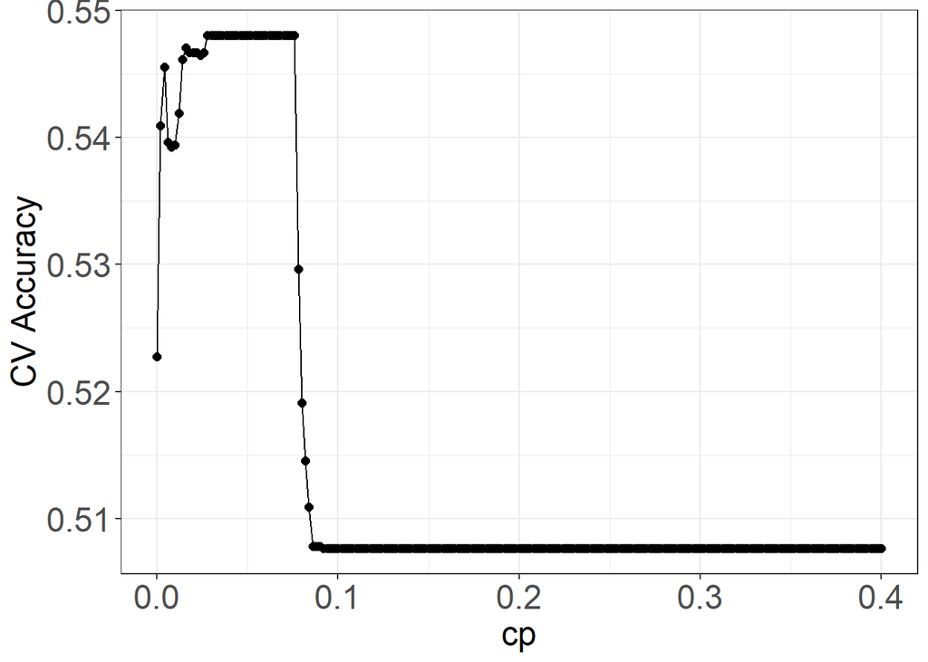

```r
ggplot(train.cart$results, aes(x = cp, y = Accuracy)) +
  geom_point(size = 2) +
  geom_line() +
  ylab("CV Accuracy") +
  theme_bw() +
  theme(axis.title=element_text(size=18), axis.text=element_text(size=18))
```

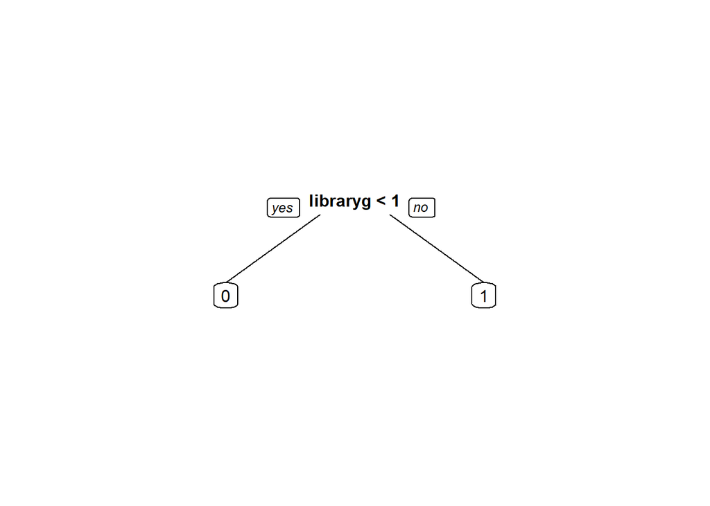

```r
mod.cart = train.cart$finalModel
prp(mod.cart)
```

```r
predict.cart = predict(mod.cart, newdata = question.test, type = "class") # why no model.matrix?
table(question.test$rate, predict.cart)
```

```
##    predict.cart
##       0   1
##   0 881 256
##   1 719 384
```

```r
cart_acc = tableAccuracy(question.test$rate, predict.cart)

# cart_acc = 0.565
#Accuracy was used to select the optimal model using the largest value.
#The final value used for the model was cp = 0.076.
```

Logistic Regression ( I tried stepwise but it took more than an hour)

```r
train.log = glm(rate ~ ., data = question.train, family = "binomial")
PredictLog = predict(train.log, newdata = question.test, type ="response")
table(question.test$rate, PredictLog > 0.5)
```

```
##
##     FALSE TRUE
##   0   701  436
##   1   541  562
```

```r
logReg_acc = tableAccuracy(question.test$rate, PredictLog > 0.5)

#LogReg_acc = 0.5638393
```

Boosting

```r
tGrid = expand.grid(n.trees = (1:50), interaction.depth = c(1,4,8,10,12,14,20),
                    shrinkage = 0.01, n.minobsinnode = 10)

set.seed(232)
# WARNING: this took me ~1 hour
train.boost <- train(rate ~ .,
                     data = question.train,
                     method = "gbm",
                     tuneGrid = tGrid,
                     trControl = trainControl(method="cv", number=5, verboseIter = TRUE),
                     metric = "Accuracy",
                     distribution = "bernoulli")
train.boost
```

```
## Stochastic Gradient Boosting
##
## 5228 samples
##  526 predictor
##    2 classes: '0', '1'
##
## No pre-processing
## Resampling: Cross-Validated (5 fold)
## Summary of sample sizes: 4182, 4182, 4182, 4184, 4182
## Resampling results across tuning parameters:
##
##   interaction.depth  n.trees  Accuracy   Kappa
##    1                  1       0.5076511  0.0000000000
##    1                  2       0.5076511  0.0000000000
##    1                  3       0.5076511  0.0000000000
```

[output cut: 354 more lines]

```r
train.boost$results
```

```
##     shrinkage interaction.depth n.minobsinnode n.trees  Accuracy
## 1        0.01                 1             10       1 0.5076511
## 51       0.01                 4             10       1 0.5076511
## 101      0.01                 8             10       1 0.5076511
## 151      0.01                10             10       1 0.5076511
## 201      0.01                12             10       1 0.5076511
## 251      0.01                14             10       1 0.5076511
## 301      0.01                20             10       1 0.5076511
## 2        0.01                 1             10       2 0.5076511
## 52       0.01                 4             10       2 0.5076511
## 102      0.01                 8             10       2 0.5076511
## 152      0.01                10             10       2 0.5078423
## 202      0.01                12             10       2 0.5080350
## 252      0.01                14             10       2 0.5084163
## 302      0.01                20             10       2 0.5093727
```

[output cut: 687 more lines]

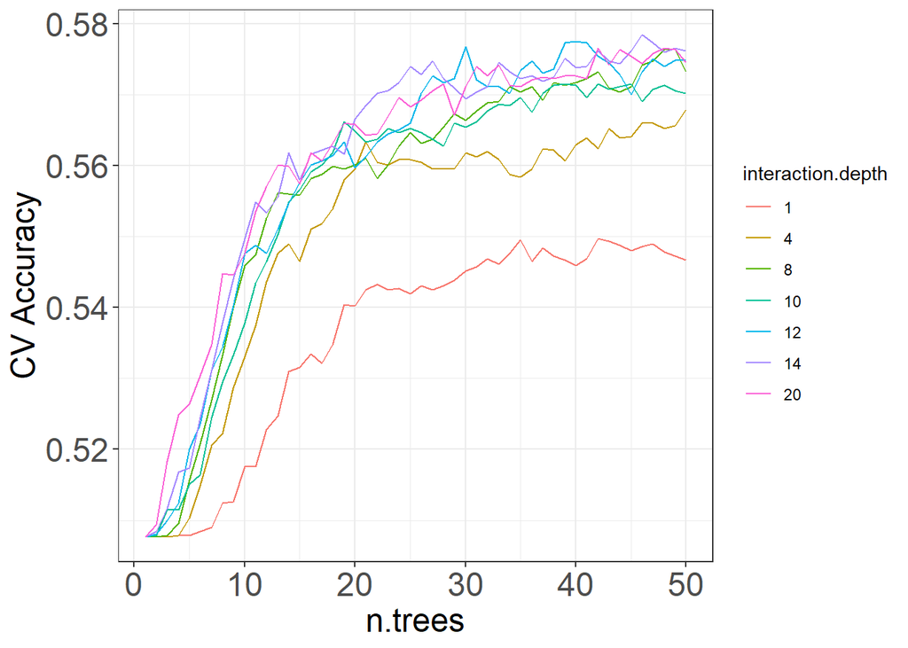

```r
ggplot(train.boost$results, aes(x = n.trees, y = Accuracy, colour = as.factor(interaction.depth))) + geom_line() +
  ylab("CV Accuracy") + theme_bw() + theme(axis.title=element_text(size=18), axis.text=element_text(size=18)) +
  scale_color_discrete(name = "interaction.depth")
```

```r
mod.boost = train.boost$finalModel

question.test.mm = as.data.frame(model.matrix(rate ~ . +0, data = question.test))
predict.boost = predict(mod.boost, newdata = question.test.mm, n.trees = 3000, type = "response")
table(question.test$rate, predict.boost < 0.5) # for some reason the probabilities are flipped in gbm
```

```
##
##     FALSE TRUE
##   0   819  318
##   1   621  482
```

```r
boost_ac = tableAccuracy(question.test$rate, predict.boost < 0.5)
boost_ac
```

```
## [1] 0.5808036
```

Tuning parameter ‘shrinkage’ was held constant at a value of 0.01 Tuning parameter ‘n.minobsinnode’ was held constant at a value of 10 Accuracy was used to select the optimal model using the largest value. The final values used for the model were n.trees = 46, interaction.depth = 14, shrinkage = 0.01 and n.minobsinnode = 10.

Now we are going to Boostrap to assess the variability of the performance metrics

```r
all_metrics <- function(data, index) {
  responses <- data$response[index]
  predictions <- data$prediction[index]
  accuracy = tableAccuracy(responses, predictions)
  tab = table(responses, predictions)
  TPR = tab[2,2]/(tab[2,2]+tab[2,1])
  FPR = tab[1,2]/(tab[1,2]+tab[1,1])
  return(c(accuracy,TPR,FPR))
}
```

```r
          ###### Random Forests ######
RF_test_set = data.frame(response = question.test$rate, prediction = predict.rf)

# do bootstrap
set.seed(892)
RF_boot <- boot(RF_test_set, all_metrics, R = 10000)
RF_boot
```

```
##
## ORDINARY NONPARAMETRIC BOOTSTRAP
##
##
## Call:
## boot(data = RF_test_set, statistic = all_metrics, R = 10000)
##
##
## Bootstrap Statistics :
##      original        bias    std. error
## t1* 0.5794643 -9.017857e-06  0.01043322
## t2* 0.6001813  9.921682e-05  0.01480461
## t3* 0.4406332  1.052985e-04  0.01478553
```

```r
#Confidence interalls
boot.ci(RF_boot, index = 1, type = "basic")
```

```
## BOOTSTRAP CONFIDENCE INTERVAL CALCULATIONS
## Based on 10000 bootstrap replicates
##
## CALL :
## boot.ci(boot.out = RF_boot, type = "basic", index = 1)
##
## Intervals :
## Level      Basic
## 95%   ( 0.5594,  0.5996 )
## Calculations and Intervals on Original Scale
```

```r
boot.ci(RF_boot, index = 2, type = "basic")
```

```
## BOOTSTRAP CONFIDENCE INTERVAL CALCULATIONS
## Based on 10000 bootstrap replicates
##
## CALL :
## boot.ci(boot.out = RF_boot, type = "basic", index = 2)
##
## Intervals :
## Level      Basic
## 95%   ( 0.5712,  0.6289 )
## Calculations and Intervals on Original Scale
```

```r
boot.ci(RF_boot, index = 3, type = "basic")
```

```
## BOOTSTRAP CONFIDENCE INTERVAL CALCULATIONS
## Based on 10000 bootstrap replicates
##
## CALL :
## boot.ci(boot.out = RF_boot, type = "basic", index = 3)
##
## Intervals :
## Level      Basic
## 95%   ( 0.4116,  0.4698 )
## Calculations and Intervals on Original Scale
```

```r
        ###### CART ############
cart_test_set = data.frame(response = question.test$rate, prediction = predict.cart)

# do bootstrap
set.seed(892)
cart_boot <- boot(cart_test_set, all_metrics, R = 10000)
cart_boot
```

```
##
## ORDINARY NONPARAMETRIC BOOTSTRAP
##
##
## Call:
## boot(data = cart_test_set, statistic = all_metrics, R = 10000)
##
##
## Bootstrap Statistics :
##      original        bias    std. error
## t1* 0.5647321  8.066964e-05  0.01056435
## t2* 0.3481414 -1.185891e-04  0.01439341
## t3* 0.2251539 -1.612184e-04  0.01240069
```

```r
#Confidence interalls
boot.ci(cart_boot, index = 1, type = "basic")
```

```
## BOOTSTRAP CONFIDENCE INTERVAL CALCULATIONS
## Based on 10000 bootstrap replicates
##
## CALL :
## boot.ci(boot.out = cart_boot, type = "basic", index = 1)
##
## Intervals :
## Level      Basic
## 95%   ( 0.5442,  0.5857 )
## Calculations and Intervals on Original Scale
```

```r
boot.ci(cart_boot, index = 2, type = "basic")
```

```
## BOOTSTRAP CONFIDENCE INTERVAL CALCULATIONS
## Based on 10000 bootstrap replicates
##
## CALL :
## boot.ci(boot.out = cart_boot, type = "basic", index = 2)
##
## Intervals :
## Level      Basic
## 95%   ( 0.3204,  0.3767 )
## Calculations and Intervals on Original Scale
```

```r
boot.ci(cart_boot, index = 3, type = "basic")
```

```
## BOOTSTRAP CONFIDENCE INTERVAL CALCULATIONS
## Based on 10000 bootstrap replicates
##
## CALL :
## boot.ci(boot.out = cart_boot, type = "basic", index = 3)
##
## Intervals :
## Level      Basic
## 95%   ( 0.2003,  0.2493 )
## Calculations and Intervals on Original Scale
```

```r
        ###### Logistic Regression ######
LR_test_set = data.frame(response = question.test$rate, prediction = PredictLog)

# do bootstrap
set.seed(892)
LR_boot <- boot(RF_test_set, all_metrics, R = 10000)
LR_boot
```

```
##
## ORDINARY NONPARAMETRIC BOOTSTRAP
##
##
## Call:
## boot(data = RF_test_set, statistic = all_metrics, R = 10000)
##
##
## Bootstrap Statistics :
##      original        bias    std. error
## t1* 0.5794643 -9.017857e-06  0.01043322
## t2* 0.6001813  9.921682e-05  0.01480461
## t3* 0.4406332  1.052985e-04  0.01478553
```

```r
#Confidence interalls
boot.ci(LR_boot, index = 1, type = "basic")
```

```
## BOOTSTRAP CONFIDENCE INTERVAL CALCULATIONS
## Based on 10000 bootstrap replicates
##
## CALL :
## boot.ci(boot.out = LR_boot, type = "basic", index = 1)
##
## Intervals :
## Level      Basic
## 95%   ( 0.5594,  0.5996 )
## Calculations and Intervals on Original Scale
```

```r
boot.ci(LR_boot, index = 2, type = "basic")
```

```
## BOOTSTRAP CONFIDENCE INTERVAL CALCULATIONS
## Based on 10000 bootstrap replicates
##
## CALL :
## boot.ci(boot.out = LR_boot, type = "basic", index = 2)
##
## Intervals :
## Level      Basic
## 95%   ( 0.5712,  0.6289 )
## Calculations and Intervals on Original Scale
```

```r
boot.ci(LR_boot, index = 3, type = "basic")
```

```
## BOOTSTRAP CONFIDENCE INTERVAL CALCULATIONS
## Based on 10000 bootstrap replicates
##
## CALL :
## boot.ci(boot.out = LR_boot, type = "basic", index = 3)
##
## Intervals :
## Level      Basic
## 95%   ( 0.4116,  0.4698 )
## Calculations and Intervals on Original Scale
```

```r
        ###### Boosting ######
boosting_test_set = data.frame(response = question.test$rate, prediction = predict.boost)

# do bootstrap
set.seed(892)
boosting_boot <- boot(RF_test_set, all_metrics, R = 10000)
boosting_boot
```

```
##
## ORDINARY NONPARAMETRIC BOOTSTRAP
##
##
## Call:
## boot(data = RF_test_set, statistic = all_metrics, R = 10000)
##
##
## Bootstrap Statistics :
##      original        bias    std. error
## t1* 0.5794643 -9.017857e-06  0.01043322
## t2* 0.6001813  9.921682e-05  0.01480461
## t3* 0.4406332  1.052985e-04  0.01478553
```

```r
#Confidence interalls
boot.ci(boosting_boot, index = 1, type = "basic")
```

```
## BOOTSTRAP CONFIDENCE INTERVAL CALCULATIONS
## Based on 10000 bootstrap replicates
##
## CALL :
## boot.ci(boot.out = boosting_boot, type = "basic", index = 1)
##
## Intervals :
## Level      Basic
## 95%   ( 0.5594,  0.5996 )
## Calculations and Intervals on Original Scale
```

```r
boot.ci(boosting_boot, index = 2, type = "basic")
```

```
## BOOTSTRAP CONFIDENCE INTERVAL CALCULATIONS
## Based on 10000 bootstrap replicates
##
## CALL :
## boot.ci(boot.out = boosting_boot, type = "basic", index = 2)
##
## Intervals :
## Level      Basic
## 95%   ( 0.5712,  0.6289 )
## Calculations and Intervals on Original Scale
```

```r
boot.ci(boosting_boot, index = 3, type = "basic")
```

```
## BOOTSTRAP CONFIDENCE INTERVAL CALCULATIONS
## Based on 10000 bootstrap replicates
##
## CALL :
## boot.ci(boot.out = boosting_boot, type = "basic", index = 3)
##
## Intervals :
## Level      Basic
## 95%   ( 0.4116,  0.4698 )
## Calculations and Intervals on Original Scale
```

Part C: I would change the threshold of what is a useful questions, the score must now be > 3. then I would make sure to minimize the FPR and maximize the TPR